# Гипотезы да АБ-тесты: доля, среднее и дисперсия

Филипп

2018-05-24

## Agenda

- Как проверять гипотезы
- Точные и асимптотические критерии
- Гипотезы о долях
- Гипотезы о средних
- Гипотезы о дисперсиях

## Примеры гипотез

- В Австралии женщин дискриминируют на рынке труда!
- В Питере люди любят кофе больше, чем в москве!
- Пауль - настоящий прорицатель! Его предсказания всегда сбываются!
- Доходности по акциям Яндекса имеют нормальное распределение!

## Что делать с гипотезами

- Можно собирать данные и смотреть не противоречат ли им гипотезы
- Это не очень достоверно, надо быть готовым к ошибкам
- Гипотезы нельзя принмать, их не отвергают

## Большая ложь агента $007$

- Предпочитает мартини взболтанным, но не смешанным
- Как проверить правда это или пафос

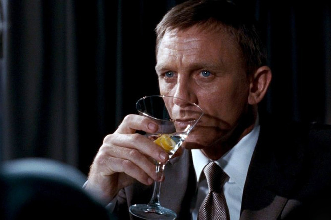

## Эксперимент

[figure not shown]

- Завязываем агенту глаза, предлагаем взболтанный и смешанный мартини
- Если больше понравился взболтанный $X_i = 1$

## Формализация гипотезы

$$\begin{aligned}
H_0: & \quad \text{Джеймс бонд не различает напитки} \\
H_1: & \quad \text{Бонд различает напитки}
\end{aligned}$$

Выбока: $X_1, \ldots, X_n$. Если Бонд не различает два напитка, он берёт их наугад. Сформулируем это в терминах $X \sim Bern(p)$.

$$\begin{aligned}
H_0: & \quad p = 0.5 \\
H_1: & \quad p \ne 0.5
\end{aligned}$$

Можно выбрать одностороннюю альтернативу. Что это будет означать?

## Формализация гипотезы

- Пусть $10$ экспериментов показали, что $\hat{p}=0.6$
- Джеймс Бонд различает?
- Да! Число 0.6 больше, чем 0.5!

## Формализация гипотезы

- Пусть $10$ экспериментов показали, что $\hat{p}=0.6$
- Джеймс Бонд различает?
- Да! Число 0.6 больше, чем 0.5!
- $\hat{p}$ - случайная величина, если продолжим собирать выборку, может измениться
- Хотим узнать при текущем объёме выборки насколько $\hat{p}$ близко к $0.5$

## Доверительный интервал

- Секундочку… Наша доля имеет асимптотически нормальное распределение

$$\hat{p} \sim N \left(p, \frac{p(1-p)}{n} \right)$$

- Доверительный интервал говорит о точности оценки

$$P\left(\hat{p} - 2 \sqrt{\frac{\hat{p} \cdot (1 - \hat{p})}{n}} \le p \le \hat{p} + 2 \sqrt{\frac{\hat{p} \cdot (1 - \hat{p})}{n}} \right) = 0.95.$$

> Воспользуемся этим!

## Доверительный интервал

```r
p_hat = 0.6
n = 10

sd_p = sqrt(p_hat*(1-p_hat)/n)
p_left  = p_hat - qnorm(1-0.05/2)*sd_p
p_right = p_hat + qnorm(1-0.05/2)*sd_p
cat('Параметр p с вероятностью 95% лежит между',p_left, 'и', p_right, '\n')
cat('Ширина интервала:', p_right - p_left)
```

```
## Параметр p с вероятностью 95% лежит между 0.2963637 и 0.9036363
## Ширина интервала: 0.6072726
```

- Широкий диапазон, в него попало $0.5 \Rightarrow$ Джеймс может врать

## Мера близости

- Если расстояние $\hat{p} - 0.5$ маленькое, Бонд не может распознавать напитки
- Что значит маленькое?

## Мера близости

- Если расстояние $\hat{p} - 0.5$ маленькое, Бонд не может распознавать напитки

Мы знаем, что

$$\hat p \sim N \left(p, \frac{p(1-p)}{n} \right)$$

Если наша гипотеза верна, то

$$\hat p \sim N \left(0.5, \frac{0.5(1-0.5)}{10} \right)$$

## Мера близости

- Значит расстояние распределено как

$$\hat p - 0.5 \sim N \left(0, \frac{0.5(1-0.5)}{10} \right)$$

- Для удобства можно перезаписать как

$$\frac{\hat p - 0.5}{\sqrt{\frac{0.5(1-0.5)}{10}}} \sim N (0,1)$$

> Это и есть статистика для проверки гипотезы

## Мера близости

- Мы выяснили как распределно “расстояние”" до значения $0.5$ при верности нулевой гипотезы
- Осталось выбрать порог, при котором мы будем считать, что $H_0$ верна
- Если альтернатива двусторонняя, очень большие и очень маленькие значения статистики говорят против нашей гипотезы

## Уровень значимости

- Если мы отвергаем $H_0$, когда она верна - мы ошибаемся
- Фиксируем число ошибок, $\alpha$ - уровень значимости (обычно берут 1% 5% или 10%)
- Если мы упаковываем $100$ парашютов на уровне значимости $5\%$, то пять парашютистов умрут, и мы готовы с этим смириться
- Если статистика попала в $1-\alpha$% доверительный интервал, то данные не противоречат гипотезе

## Картинка для Бонда

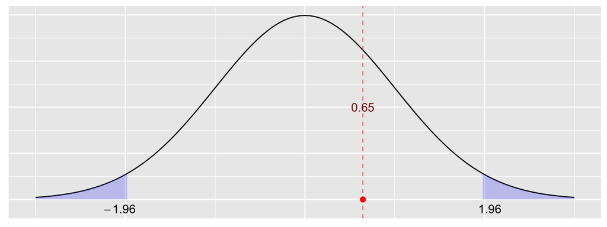

```r
p_hat = 0.6
n = 10

sd_p = sqrt(p_hat*(1-p_hat)/n)

z_stat = (p_hat - 0.5)/sd_p   # считаем наблюдаемую статистику
z_stat_picture(z_stat, alpha = 0.05, alternative = 'two-sided')
```

## Картинка для Бонда

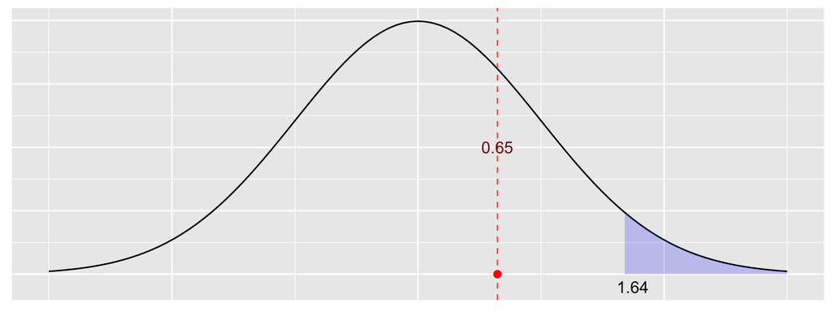

```r
p_hat = 0.6
n = 10

sd_p = sqrt(p_hat*(1-p_hat)/n)

z_stat = (p_hat - 0.5)/sd_p   # считаем наблюдаемую статистику
z_stat_picture(z_stat, alpha = 0.05, alternative = 'greater')
```

## Пояснения для картинок:

- Голубая область - критическая область, при попадании статистики в неё - гипотеза отвергается, “расстояние”" оказывается большим
- В нашем случае наблюдаемое значение статистики попало в доверительную область
- Гипотеза о том, что Бонд не различает между собой напитки, не отвергается для обеих альтернатив

## Алгоритм проверки гипотез

1. Задаём уровень значимости $\alpha$
2. Формулируем нулевую и альтернативную гипотезы.
3. Выбираем статистику для проверки гипотезы.
4. Находим наблюдаемое значение статистики по выборке.
5. Находим критические точки для выбранной статистики.
6. Сравниваем наблюдаемое значение с критическими.

## Ошибки, которые мы совершаем

|  | $H_0$ верна | $H_0$ не верна |
| --- | --- | --- |
| $H_0$ не отвергается | ok | Ошибка $II$ рода |
| $H_0$ отвергается | Ошибка $I$ рода | ok |

- Мы можем делать ошибки двух видов
- Вероятность ошибки первого рода, $P(H_0 \text{ отвергнута} \mid H_0 \text{ верна})$, называют **уровнем значимости** и обозначают как $\alpha$.
- Вероятность ошибки второго рода, $P(H_0 \text{ не отвергнута} \mid H_0 \text{ не верна})$, обозначают как $\beta$. Величину $1-\beta$ называют **мощностью критерия.**

## Ошибки первого и второго рода

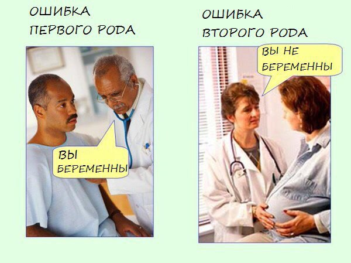

## Презумпция нулевой гипотезы

- Ошибки первого и второго рода неравнозначны, ошибка первого рода критичнее (фиксируем её в начале)
- Ошибка второго рода минимизируется по остаточному принципу

> **Презумпция невиновности:** подсудимый по умолчанию невиновен. Если нет доказательств обратному, нельзя утверждать, что он преступник, даже если он совершил преступление.

## $P$-значение

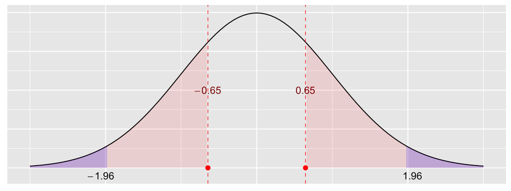

- Цифры $\pm 1.96$ - это критические точки, голубая площадь - это $\alpha$
- Цифры $\pm 0.65$ - это наблюдаемое значение, красная площадь - это $pvalue$

## Лёгкий рецепт для гипотез

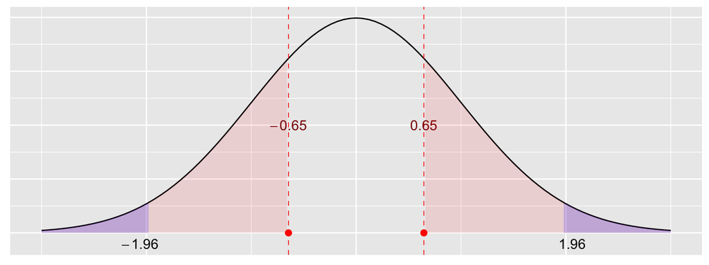

- если красная площадь больше синей, $pvalue > \alpha$, гипотеза не отвергается, статистика попала в доверительную область
- если красная площадь меньше синей, то наблюдаемое значение в хвосте и гипотеза отвергается

## Подсчёт $pvalue$

Для нормального распределения:

```r
z_stat
2*pnorm(-z_stat)
```

```
## [1] 0.6454972
## [1] 0.518605
```

> p-значение упрощает проверку гипотез. В нашем случае оно больше уровня значимости, следовательно гипотеза не отвергается.

## Более формально про $pvalue$

**Достигаемый уровень значимости** или **P-значение** - это вероятность при справедливости нулевой гипотезы получить такое же значение статистики, как в эксперименте или ещё более экстремальное.

$$p = P(z \ge z_{\text{набл.}} \mid H_0)$$

## Параметрические критерии

- Обычно нас интересуют средние, доли и дисперсии
- Будем проверять гипотезы о них
- Каждый критерий для проверки гипотезы - небольшая теорема со своими предпосылками
- Сегодня посмотрим параметрические критерии
- В гипотезах для таких критериев высказывается предположение о значении параметра распределения, из которого предположительно поступила выборка

## $Z$-статистика для доли

Выборка: $X_1, \ldots, X_n \sim iid \hspace{2mm} Bern(p)$

Нулевая и альтернативная гипотезы:

$$\begin{aligned}
&H_0: \hspace{2mm} p = p_0 \\
&H_1: \hspace{2mm} p < \ne > p_0
\end{aligned}$$

При верности нулевой гипотезы

$$Z = \frac{\hat{p} - p_0}{\sqrt{\frac{p_0(1-p_0)}{n}}} \sim N(0,1)$$

## Задачка про присяжных

- В 70-х годах известный педиатр и автор книг по воспитанию детей Бенджамин Спок был арестован за участие в антивоенной демонстрации. Его дело должен был рассматривать суд присяжных.
- Присяжные назначаются многоступенчатой процедурой. На последнем этапе оказалось только 90 женщин.
- Протест адвокатов. Обвинение специально пытается сделать итоговый состав благосклонным к подсудимому, убирая женщин.
- Был ли отбор беспристрастным?

## Задачка про присяжных

$$\begin{aligned}
&H_0: \hspace{2mm} p = 0.5 \hspace{2mm} \text{Отбор беспрестрастен} \\
&H_1: \hspace{2mm} p < 0.5 \hspace{2mm} \text{Женщин берут реже}
\end{aligned}$$

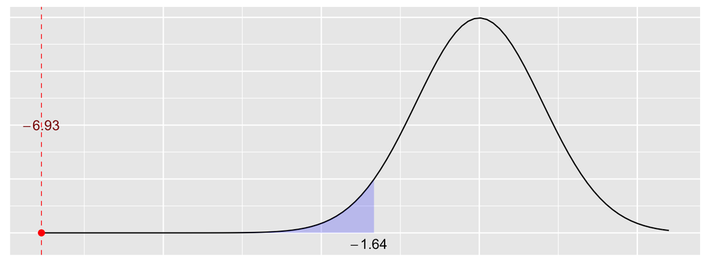

```
## p-value: 2.131096e-12
```

```r
n = 300
p_hat = 90/300
z_stat = (p_hat - 0.5)/sqrt(0.5*(1-0.5)/n)
p_value = pnorm(z_stat)
cat('p-value:',p_value)
z_stat_picture(z_stat, alpha = 0.05, alternative = 'less')
```

## Задачка про присяжных

- Критическая область - левосторонняя
- Наблюдаемое значение далеко в хвосте, гипотеза о беспристрастности отвергается
- $pvalue$ получилось гораздо ниже $0.05$

## Проверка гипотезы в R

```r
test_res = prop.test(90, 300, p = 0.5, alternative = "less",
                     conf.level = 0.95, correct = FALSE)
test_res
```

```
##
##  1-sample proportions test without continuity correction
##
## data:  90 out of 300, null probability 0.5
## X-squared = 48, df = 1, p-value = 2.131e-12
## alternative hypothesis: true p is less than 0.5
## 95 percent confidence interval:
##  0.0000000 0.3451483
## sample estimates:
##   p
## 0.3
```

```r
test_res$p.value
test_res$estimate
```

```
## [1] 2.131096e-12
##   p
## 0.3
```

## $Z$-статистика для доли для двух независимых выборок

Выборки: $X_1, \ldots, X_{n_1} \sim iid \hspace{2mm} Bern(p)$ и $Y_1, \ldots, Y_{n_2} \sim iid \hspace{2mm} Bern(p)$

Нулевая и альтернативная гипотезы:

$$\begin{aligned}
&H_0: \hspace{2mm} p_1 = p_2 \\
&H_1: \hspace{2mm} p_1 < \ne > p_2
\end{aligned}$$

При верности нулевой гипотезы:

$$\begin{aligned}
\hat{p}_1 &\sim N\left(p, \frac{p(1-p)}{n_1} \right) \\
\hat{p}_2 &\sim N\left(p, \frac{p(1-p)}{n_2} \right)
\end{aligned}$$

## $Z$-статистика для доли для двух независимых выборок

Статистика для проверки гипотезы:

$$Z = \frac{\hat p_1 - \hat p_2}{\sqrt{P(1-P)\frac{n_1 + n_2}{n_1 n_2}}} \sim N(0,1),$$

$$P = \frac{m_1 + m_2}{n_1 + n_2} = \frac{\hat p_1 n_1 + \hat p_2 n_2}{n_1 + n_2}$$

## Рейтинг премьер-министра

- Из 1600 опрошенных граждан Великобретании 944 высказали одобрение деятельности премьер-министра
- Через 6 месяцев одобрение высказали 880 из 1600 опрошенных
- Изменился ли рейтинг премьера?

## Рейтинг премьер-министра

$$\begin{aligned}
&H_0: \hspace{2mm} p_1 = p_2 \hspace{2mm} \text{Рейтинг не поменялся} \\
&H_1: \hspace{2mm} p_1 \ne p_2 \hspace{2mm} \text{Рейтинг поменялся}
\end{aligned}$$

> В качестве альтернативы будет уместна двусторонняя гипотеза, так как рейтинг мог измениться в любую сторону.

## Рейтинг премьер-министра

```r
n1 = 1600
m1 = 944

n2 = 1600
m2 = 880

p1_hat = m1/n1
p2_hat = m2/n2
P = (m1 + m2)/(n1 + n2)

z_stat = (p1_hat - p2_hat)/(sqrt(P*(1-P)*(n1+n2)/(n1*n2)))

p_value = 2*pnorm(-z_stat)
cat('p-value:',p_value)
```

```
## p-value: 0.02229829
```

## Рейтинг премьер-министра

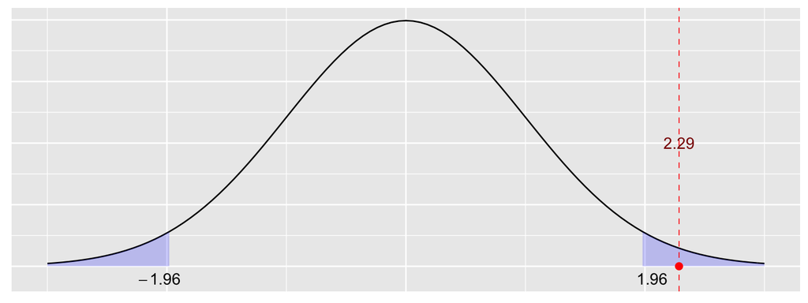

```r
z_stat_picture(z_stat, alpha = 0.05, alternative = 'two-sided')
```

## Рейтинг премьер-министра

То же самое внутренними средствами R

```r
test_res = prop.test(x = c(m1, m2), n = c(n1, n2), correct = FALSE)
test_res
```

```
##
##  2-sample test for equality of proportions without continuity
##  correction
##
## data:  c(m1, m2) out of c(n1, n2)
## X-squared = 5.2224, df = 1, p-value = 0.0223
## alternative hypothesis: two.sided
## 95 percent confidence interval:
##  0.005721636 0.074278364
## sample estimates:
## prop 1 prop 2
##   0.59   0.55
```

- Протокол очень богатый! Задавайте вопросы :)
- Какие проблемы у этого теста?

## Рейтинг премьер-министра

- В обоих опросах участвовали одни и те же люди, выборки связаны между собой
- Z критерий предполагает, что выборки независимы
- Нужен другой критерий

## Рейтинг премьер-министра

```r
n = 1600
f = 150
g = 86

z_stat = (f - g)/(sqrt(f + g - (f-g)^2/n))

p_value = 2*pnorm(-z_stat)
cat('p-value:',p_value)
```

```
## p-value: 2.804011e-05
```

- гипотеза о том, что рейтинг премьера не изменился после такой очистки начинает отвергаться более уверенно

## Резюме про доли

- Проверять гипотезы о долях помогает Z-тест
- Он имеет асимптотически нормальное распределение
- Статстика для связных выборок и независимых считается немного по-разному
- Обе статистики для двух долей имеют асимптотическое распределение

## Гипотезы о среднем для нормального

Выборка: $X_1, \ldots, X_n \sim iid \hspace{1mm} N(\mu, \sigma^2)$

Нулевая и альтернативная гипотезы:

$$\begin{aligned}
&H_0: \hspace{2mm} \mu = \mu_0 \\
&H_1: \hspace{2mm} \mu < \ne > \mu_0
\end{aligned}$$

Статистика для проверки гипотезы:

$$Z = \frac{\hat \mu - \mu_0}{\frac{\sigma}{\sqrt{n}}} \sim N(0,1)$$

## Гипотезы о среднем для нормального

Статистика с прошлого слайда работает только при известной дисперсии. Если дисперсия неизвестна, нужно оценить её и использовать статистику

$$t = \frac{\hat \mu - \mu_0}{\frac{s}{\sqrt{n}}} \sim t(n-1)$$

- Распределение у статистики точное только если выборка нормальная

## Вес детей при рождении

- Средний вес детей при рождении 3300 г, у женщин, живущих за чертой бедности - 2800 г
- 25 женщин, живущих за чертой бедности, участвовали в экспериментальной программе ведения беременности
- Средний вес их детей составил 3075 г, стандартное отклонение 500 г
- Эффективна ли программа?

## Вес детей при рождении

В качестве альтернативы берём правостороннюю, так как вес детей должен был возрасти

$$\begin{aligned}
&H_0: \hspace{2mm} \mu = 2800 \hspace{2mm} \text{Программа не помогла}\\
&H_1: \hspace{2mm} \mu > 2800 \hspace{2mm} \text{Программа помогла}
\end{aligned}$$

```r
mu_0 = 2800

mu_hat = 3075
s = 500
n = 25

t_stat = sqrt(n)*(mu_hat - mu_0)/s

p_value = pt(-t_stat, df=n-1)
cat('p-value:',p_value)
```

```
## p-value: 0.005573915
```

## Вес детей при рождении

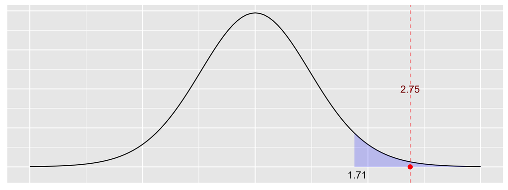

- Наблюдаемое значение попало в критическую область, гипотеза об отсутствии эффекта от программы отвергается

## Гипотезы о среднем в общем случае

> Если выборка не распределена нормально, то наша оценка для среднего будет иметь асимптотически нормальное распределение. Для проверки гипотезы будет использоваться та же самая статистика, но выводы будут асимптотическми

$$z = \frac{\hat \mu - \mu_0}{\frac{\hat \sigma}{\sqrt{n}}} \sim N(0,1)$$

## Двухвыборочный критерий для средних

Выборки:

$$\begin{aligned}
& X_1, \ldots, X_{n_1} \sim iid \hspace{1mm} N(\mu_1, \sigma_1^2) \\
& Y_1, \ldots, Y_{n_2} \sim iid \hspace{1mm} N(\mu_2, \sigma_2^2)
\end{aligned}$$

Нулевая и альтернативная гипотезы:

$$\begin{aligned}
&H_0: \hspace{2mm} \mu_1 = \mu_2 \\
&H_1: \hspace{2mm} \mu_1 < \ne > \mu_2
\end{aligned}$$

Статистика для проверки гипотезы:

$$Z = \frac{\hat \mu_1 - \hat \mu_2}{\sqrt{ \frac{\sigma_1^2}{n_1} + \frac{\sigma_2^2}{n_2}} }$$

## Разные ситуации

- Если дисперсии известны и выборки нормально распределены, то

$$\frac{\hat \mu_1 - \hat \mu_2}{\sqrt{ \frac{\sigma_1^2}{n_1}} + \frac{\sigma_2^2}{n_2}}\sim N(0,1)$$

- Если дисперсии неизвестны, но равны, то

$$t = \frac{\hat \mu_1 - \hat \mu_2}{\sqrt{ \frac{s^2}{n_1} + \frac{s^2}{n_2}}} \sim t(n_1 + n_2 -2)$$

Дисперсия считается по формуле:

$$s^2 = \frac{(n_1-1)*s_1^2 + (n_2-1)*s_2^2}{n_1 + n_2 -2}$$

## Разные ситуации

- Когда дисперсии неизвестные и разные, возникает проблема. Если заменить неизвестные дисперсии на оценки то

$$t = \frac{\hat \mu_1 - \hat \mu_2}{\sqrt{ \frac{s_1^2}{n_1} + \frac{s_2^2}{n_2}} } \sim t(\nu).$$

- Это распределение будет приближённым, точного распределения для этой статистики нет. Это называется [проблемой Беренца-Фишера.](https://ru.wikipedia.org/wiki/Нерешённые_проблемы_статистики)

## Разные ситуации

- Число степеней свободы считатся по сложной формуле

$$\nu = \frac{ \left(\frac{s_1^2}{n_1} + \frac{s_2^2}{n_2} \right)^2 }{ \frac{s_1^4}{n_1^2(n_1 -1)} + \frac{s_2^4}{n_2^2(n_2-1)}}$$

- У вас в лекциях этой ситуации не было

## Стоимость домов в Сиэтле

- имеются [данные о продажной стоимости](https://yadi.sk/i/Gn5GkSNV3Winsn) недвижимости в Сиэтле для 50 сделок в 2001 году и 50 в 2002.
- Изменились ли в среднем цены?

## Стоимость домов в Сиэтле

$$\begin{aligned}
&H_0: \hspace{2mm} \mu_1 = \mu_2 \hspace{2mm} \text{Стоимость не поменялась} \\
&H_1: \hspace{2mm} \mu_1 \ne \mu_2 \hspace{2mm} \text{Стоимость поменялась}
\end{aligned}$$

```r
df = read.csv('/Users/fulyankin/Yandex.Disk.localized/R/R_prob_data/seattle.csv', sep='\t')

# Вытащим цены в отдельные векторы
price_2002 = df[df$Year == 2002,]$Price
price_2001 = df[df$Year == 2001,]$Price

# Расчитаем всё необходимое для проверки гипотезы
n_1 = length(price_2001)
n_2 = length(price_2002)

mu_1 = mean(price_2001)
mu_2 = mean(price_2002)

s_1 = var(price_2001)
s_2 = var(price_2002)

t_stat = (mu_1 - mu_2)/sqrt(s_1/n_1 + s_2/n_2)
```

## Стоимость домов в Сиэтле

Мы не можем сказать, что дисперсии известны или равны, придётся использовать сложную статистику со сложной формулой

```r
a = (s_1/n_1 + s_2/n_2)^2
b = s_1^2/(n_1^2*(n_1-1)) + s_2^2/(n_2^2*(n_2-1))
a/b
```

```
## [1] 71.89522
```

Можно попробовать сначала проверить гипотезу о равенстве дисперсий

## Стоимость домов в Сиэтле

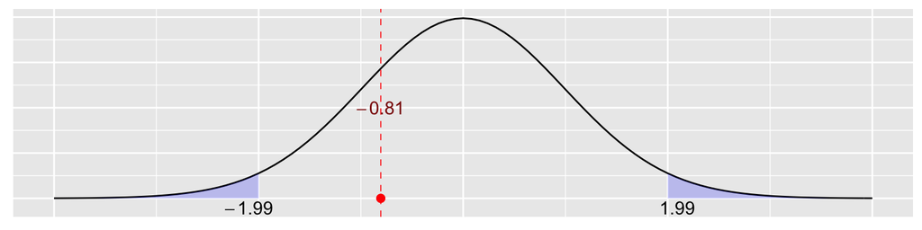

```r
t_stat_picture(t_stat, 72, alpha = 0.05, alternative = 'two-sided')
```

```r
p_value = 2*pt(t_stat, df=72)
cat('p-value:',p_value)
```

```
## p-value: 0.423054
```

гипотеза о равенстве цен не отвергается

## Стоимость домов в Сиэтле

То же самое внутренними средствами R

```r
t.test(price_2001, price_2002, var.equal = FALSE,
       alternative = "two.sided", conf.level = 0.95)
```

```
##
##  Welch Two Sample t-test
##
## data:  price_2001 and price_2002
## t = -0.80573, df = 71.895, p-value = 0.4231
## alternative hypothesis: true difference in means is not equal to 0
## 95 percent confidence interval:
##  -140.11588   59.45468
## sample estimates:
## mean of x mean of y
##  288.9265  329.2571
```

- Протокол очень богатый! Задавайте вопросы :)

## Двухвыборочный критерий для средних (связанные выборки)

- Измерения делаются на одних и тех же объектах
- Это значит, что $\bar y - \bar x$ это то же самое, что $\overline{x-y}$
- Благодаря тому, что мы можем смотреть прирост по каждому объекту, мы скатываемся к одновыборочному критерию

## Двухвыборочный критерий для средних (связанные выборки)

$$d_i = X_i - Y_i$$

$$s^2 = \frac{1}{n-1}\sum_{i=1}^n (d_i - \bar d )^2$$

$$t = \frac{\bar{d}}{s/\sqrt{n}} \sim t(n-1)$$

## Лечение детей

- 24 ребёнка прошли тест на способность к подавлению импульсивных поведенческих реакций после недели приёма метилфенидата и после недели приёма плацебо
- Каков эффект препарата?

## Лечение детей

$$\begin{aligned}
&H_0: \hspace{2mm} \mu_1 = \mu_2 \hspace{2mm} \text{Препарат неэффективен} \\
&H_1: \hspace{2mm} \mu_1 > \mu_2 \hspace{2mm} \text{Препарат хорош}
\end{aligned}$$

## Лечение детей

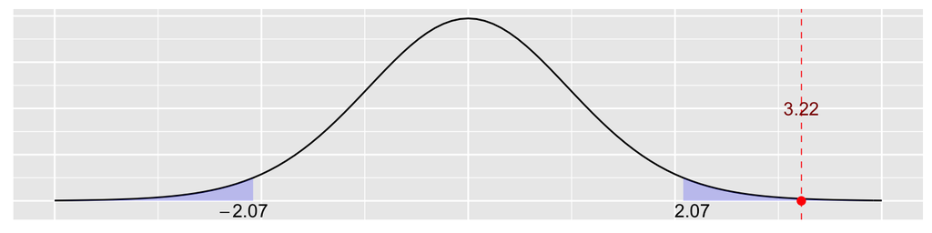

[output not shown]

```r
df = read.csv('/Users/fulyankin/Yandex.Disk.localized/R/R_prob_data/ADHD.csv', sep=' ')

d = df$D60 - df$D0
mu_d = mean(d)
s_d = sd(d)
n = nrow(df)

t_stat = mu_d/(s_d/sqrt(n))

p_value = 2*pt(t_stat, df=n-1)
cat('p-value:',p_value)

t_stat_picture(t_stat, n-1, alpha = 0.05, alternative = 'two-sided')
```

## Лечение детей

То же самое внутренними средствами R

```r
t.test(df$D60, df$D0, var.equal = FALSE, paired=TRUE,
       alternative = "two.sided", conf.level = 0.95)
```

```
##
##  Paired t-test
##
## data:  df$D60 and df$D0
## t = 3.2224, df = 23, p-value = 0.003771
## alternative hypothesis: true difference in means is not equal to 0
## 95 percent confidence interval:
##  1.775236 8.141431
## sample estimates:
## mean of the differences
##                4.958333
```

- Протокол очень богатый! Задавайте вопросы :)

## Лечение детей

Внимание! Если не учесть, что выборки связанные, можно получить неправильный результат и сделать вывод, что лекарство не помогает детям.

```r
t.test(df$D0, df$D60, var.equal = FALSE,
       alternative = "two.sided", conf.level = 0.95)
```

```
##
##  Welch Two Sample t-test
##
## data:  df$D0 and df$D60
## t = -1.4522, df = 45.671, p-value = 0.1533
## alternative hypothesis: true difference in means is not equal to 0
## 95 percent confidence interval:
##  -11.832593   1.915927
## sample estimates:
## mean of x mean of y
##  39.75000  44.70833
```

## Резюме про средние

- Если выборка распределена нормально, можно использовать t-статистику, имеющую распределение стьюдента
- Если средних два и выборки независимы, возможны три разные ситуации
- Если выборки связанные, то всё скатывается к одновыборочному критерию
- Если выборка распределена не нормально, то используются те же статистики, но они имеют асимптотичеси нормальное распределение

## Гипотезы о дисперсии для нормального

Выборка: $X_1, \ldots, X_n \sim iid \hspace{1mm} N(\mu, \sigma^2)$

Нулевая и альтернативная гипотезы:

$$\begin{aligned}
&H_0: \hspace{2mm} \sigma^2 = \sigma^2_0 \\
&H_1: \hspace{2mm} \sigma^2 < \ne > \sigma^2_0
\end{aligned}$$

## Гипотеза о дисперсии для нормального

Статистика для проверки гипотезы при известном математическом ожидании:

$$F = \frac{s^2}{\sigma_0^2} = \sum_{i=1}^n \left(\frac{X_i - \mu}{\sigma_0}\right)^2 \sim \chi^2_n.$$

Статистика для проверки гипотезы при неизвестном математическом ожидании:

$$F = \frac{s^2}{\sigma_0^2} = \frac{(n-1) s^2}{\sigma^2} =\sum_{i=1}^n \left(\frac{X_i - \bar x}{\sigma}\right)^2 \sim \chi^2_{n-1}.$$

## Задачка

> Задачки на этот критерий не будет.

## Гипотеза о равенстве дисперсий для нормального

Выборки:

$$\begin{aligned}
& X_1, \ldots, X_{n_1} \sim iid \hspace{1mm} N(\mu_1, \sigma_1^2) \\
& Y_1, \ldots, Y_{n_2} \sim iid \hspace{1mm} N(\mu_2, \sigma_2^2)
\end{aligned}$$

Нулевая и альтернативная гипотезы:

$$\begin{aligned}
&H_0: \hspace{2mm} \sigma^2_1 = \sigma^2_2 \\
&H_1: \hspace{2mm} \sigma^2_1 < \ne > \sigma^2_2
\end{aligned}$$
Статистика:

$$F = \frac{s_1^2}{s_2^2}$$

## Гипотеза о равенстве дисперсий для нормального

Статистика:
$$F = \frac{(n_1-1) \cdot s_1^2}{\sigma^2 \cdot (n_1-1)} : \frac{(n_2-1) \cdot s_2^2}{\sigma^2 \cdot(n_2-1)}.$$
$$F \sim \frac{\chi^2_{n_1-1}}{n_1-1} : \frac{\chi^2_{n_2-1}}{n_2-1} = F(n_1-1,n_2-1).$$

## Вася и Анечка <3

- Вася Сидоров прыгает вдлину на соревнованиях
- На первых была Аня Иванова (его первая любовь)
- На вторых она не была (с чего бы это…)
- Проверьте гипотезу о том, что из-за раставания Вася стал более рассеяным и точность его прыжков упала

Нулева гипотеза:

## Вася и Анечка <3

```r
first  = c(1.83, 1.64, 2.27, 1.78, 1.89, 2.33, 1.61, 2.31)
second = c(2.05, 1.07, 1.59, 1.96, 1.29, 1.52, 1.18, 1.47)

f_stat = var(first)/var(second)


f_crit = qf(0.05, df1 = length(first) - 1, df2 = length(second) - 1)
```

Гипотеза о том, что точность Васиных прыжков на обоих соревнованиях одинакова, не отвергается.

## Вася и Анечка <3

```r
var.test(first, second, alternative = 'less', conf.level = 0.95)
```

```
##
##  F test to compare two variances
##
## data:  first and second
## F = 0.74409, num df = 7, denom df = 7, p-value = 0.3532
## alternative hypothesis: true ratio of variances is less than 1
## 95 percent confidence interval:
##  0.000000 2.817898
## sample estimates:
## ratio of variances
##          0.7440892
```

## Фишер и сигареты

- [О том, почему Фишер не верил во вред сигарет](https://lpgenerator.ru/blog/2016/10/23/pochemu-otec-sovremennoj-statistiki-ne-veril-chto-kurenie-vyzyvaet-rak/)

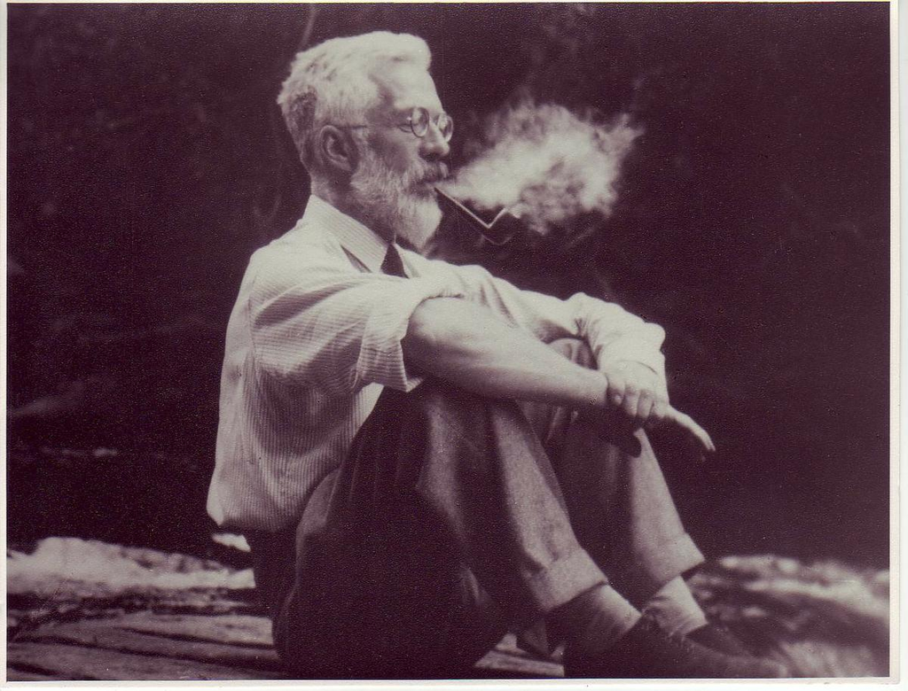

## Резюме о дисперсиях

- Для нормальных выборок можно использовать статистики Фишера
- Для двухвыборочного критерия подойдёт F-критерий
- Есть и другие статитсики для проверки гипотезы о дисперсиях, но мы в них углубляться не будем

## Значимость и существенность

- Интерес представляет не величина p-значения, а размер эффекта - степень отклонения данных от нулевой гипотезы
- На основе размера эффекта делается вывод о том, являются ли результаты практически существенными

## Значимость и несущественно

- за три года женщины, упражнявшиеся не меньше часа в день, набрали значимо меньше веса, чем женщины, упражнявшиеся меньше 20 минут в день $(p < 0.001)$
- разница в набранном весе составила 150 г.
- практическая значимость такого эффекта сомнительна

## Значимо и существенно

- в 2002 году клинические испытания гормонального препарата Премарин, облегчающего симптомы менопаузы, были досрочно прерваны
- было обнаружено, что его приём ведёт к значимому увеличению риска развития рака груди на $0.08\%$, риска инсульта на $0.08\%$ и инфаркта на $0.07\%$
- формально эффект крайне мал, но с учётом численности населения он превращается в тысячи дополнительных смертей

## Незначимо, но существенно

- лекарство, замедляющее ослабление интеллекта больных Альцгеймером
- при испытаниях выяснилось, что разница в IQ контрольной и тестовой групп составляет 13 пунктов
- разница статистически нещначима
- возможно, выборка мала для детекции эффекта и изучение лекарства стоит продолжить